# Univariate Statistics

# 1.1 Introduction

In general data is gathered for the purpose of answering a question, or more specifically, a research question but, *the data we deal within the industry is too big* to go through each and every observation.

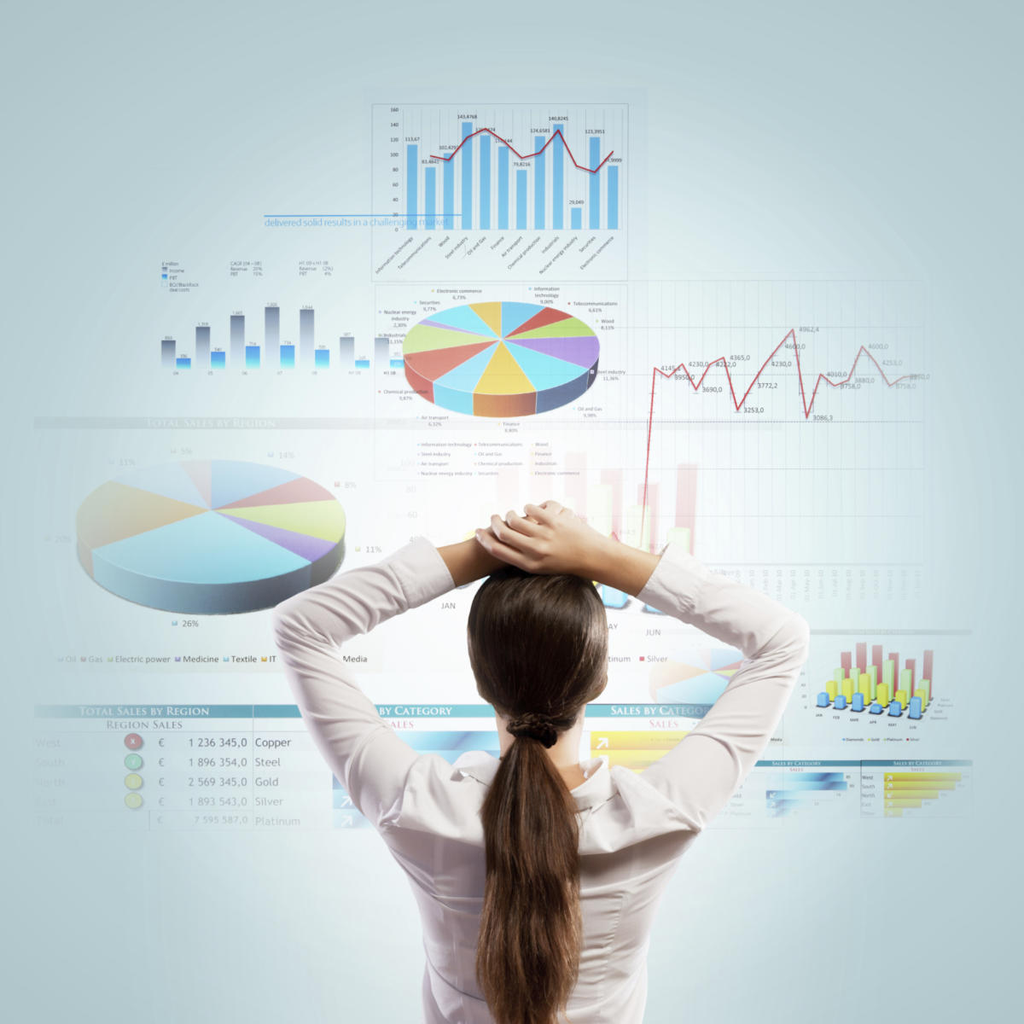

In order to understand the data, we need to come up with a way to **summarise** this so that you can quickly go through the summary and understand your data faster.

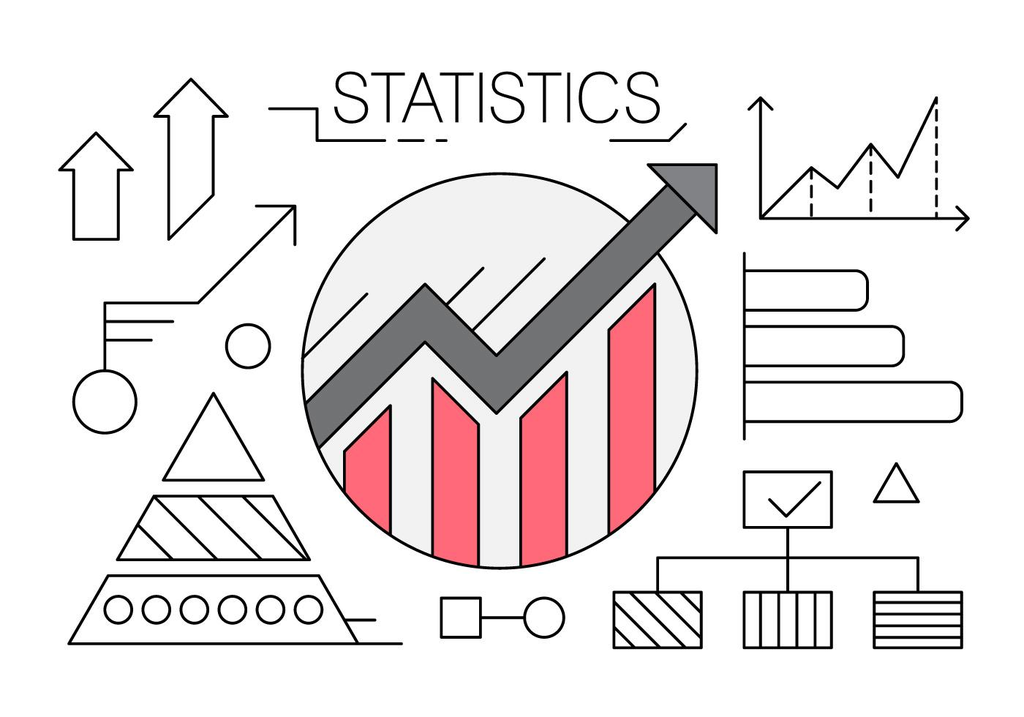

Lets look at kind of **summaries** we need to consider to understand our data in a comprehensive manner. There are **three facets** of the data that we need to summarize in order to capture all aspects of the data:

1. **Central Tendency**
2. **Variability**
3. **Shape**

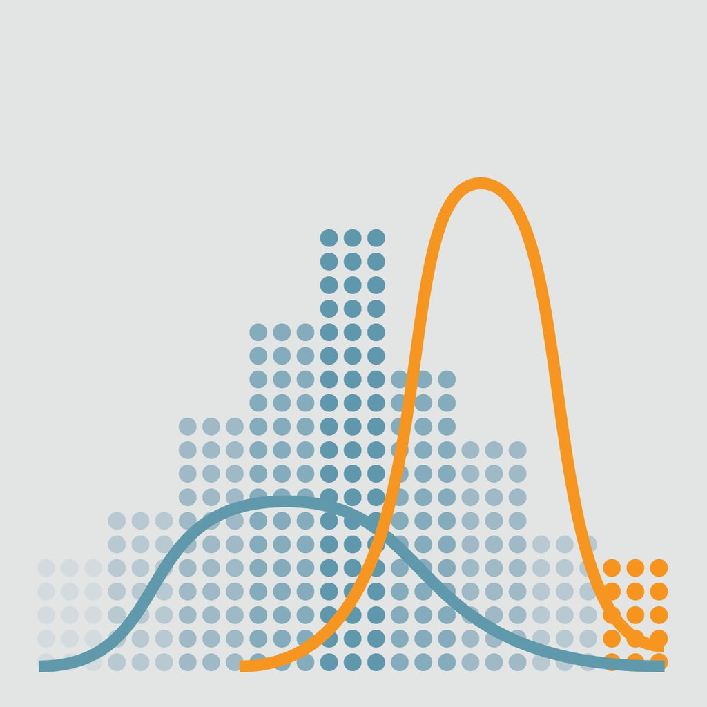

In **univariate statisitcs**, we explore each variable in a dataset separately. We look at the range of values, as well as the central tendency of the values. It describes the individual variables.

# 1.2 Measures of Central Tendency

**Central tendency** is the average behaviour of the data. Central tendency is the value of your data which is most expected outcome. There are **three measures** for central tendency:

1. **Mean**
2. **Median**
3. **Mode**

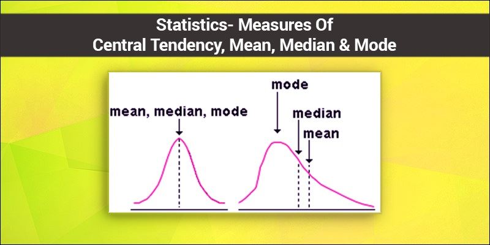

## 1.2.1 Mean

Mean is simply defined as the average of the values.

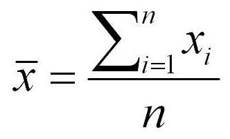

Consider the average of these numbers (1,2,3,4,5,6,7). It is 4.

## 1.2.2 Median

**Median** is defined as the middle most value when your data is sorted.

**For example**, if your data is (1,10,8,7,9,12,3), you’d sort it (1,3,7,8,9,10,12), your data has 7 elements, the middle most term will be (7+1)/2 th term which is 8.

If your data has even number of elements then you’ll have two middle most values.

**For example**, lets consider this data (1,3,7,8,9,10,12,14000). Two middle most terms are 8 & 9, median is taken as average of these two middle most values which is 8.5

You might have noticed by now that median doesnt not depend on the values of elements, only on their order in the data which makes it not so sensitive to extreme values present in the data.

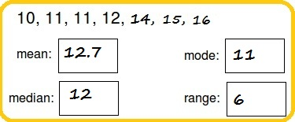

## 1.2.3 Mode

**Mode** is simply defined as the value which occurs most frequently in the data. It is mostly used for categorical variables because numerical summaries do not make sense in context of categorical variables.

A dataset can have multiple modes, since highest frequency can be equal for many categories of the categorical variable. As opposed to this mean and median for a dataset take a single value.

## 1.2.4 Use Case: **mtcars** dataset

We will start with calculating **mean** and **median** values of variable **mpg** in the data. Lets load the data first using the **data** function.

```r
data("mtcars")
```

You can view the complete dataset using the **View** function.

```r
View(mtcars)
```

To look at the head of the data, we will use **head** function.

```r
head(mtcars)
```

|  | mpg | cyl | disp | hp | drat | wt | qsec | vs | am | gear | carb |
| --- | --- | --- | --- | --- | --- | --- | --- | --- | --- | --- | --- |
| Mazda RX4 | 21.0 | 6 | 160 | 110 | 3.90 | 2.620 | 16.46 | 0 | 1 | 4 | 4 |
| Mazda RX4 Wag | 21.0 | 6 | 160 | 110 | 3.90 | 2.875 | 17.02 | 0 | 1 | 4 | 4 |
| Datsun 710 | 22.8 | 4 | 108 | 93 | 3.85 | 2.320 | 18.61 | 1 | 1 | 4 | 1 |
| Hornet 4 Drive | 21.4 | 6 | 258 | 110 | 3.08 | 3.215 | 19.44 | 1 | 0 | 3 | 1 |
| Hornet Sportabout | 18.7 | 8 | 360 | 175 | 3.15 | 3.440 | 17.02 | 0 | 0 | 3 | 2 |
| Valiant | 18.1 | 6 | 225 | 105 | 2.76 | 3.460 | 20.22 | 1 | 0 | 3 | 1 |

Lets calculate the mean of the mpg variable using the **mean** function from base R.

```r
mean(mtcars$mpg)
```

```
[1] 20.09062
```

Similarly, to calculate the median we will use **median** function.

```r
median(mtcars$mpg)
```

```
[1] 19.2
```

# 1.3 Measures of Dispersion

Lets start with discussing **variability**, datasets having same average do not neccessarily behave in a same fashion. They might differ in terms of spread. Here is an example, both the datasets have their average as 10.

(7,8,9,10,11,12,13) : 10

(-100,-50,10,90,100) : 10

You can see that the second dataset is much more spread out in comparison to the first one, inspite of them having same mean. There are many ways in which this spread can be measured:

- **Range**
- **Standard Deviation / Variance**
- **Mean Absolute Deviation (MAD)**
- **Inter Quartile Range**

## 1.3.1 Range

**Range** is simply defined as difference between minimum and maximum values in the data.

Its a very primitive measure and is rarely used.

You can observe that since it relies on extreme values in your data to start with, it is very sensitive to presence of extreme values in your data.

## 1.3.2 Standard Deviation / Variance

The **standard deviation** is a measure that is used to quantify the amount of variation or dispersion of a set of data values about the mean value.

It is useful in comparing sets of data which may have the same mean but a different range.

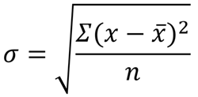

**Variance** is simply square of the standard deviation.

## 1.3.3 Mean Absolute Deviation (MAD)

Spread is defined as deviation of individual values from the mean of the data. If you simply try to add these deviations and take average, positive and negative deviations will cancel each other out. Average absolute values of these deviation is one way to avoid effect of signs in the deviations.

## 1.3.4 Inter Quartile Range (IQR)

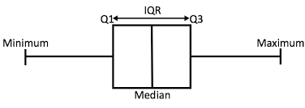

**IQR** is defined as difference between q1 and q3 where q1, q3 are first and third quartiles respectively.

Quartiles are the values which divide your data into 4 parts.

Median is second quartile or q2, it divides into two equal parts.

You can consider q1 to be median of the first part and q3 to be median of the second part.

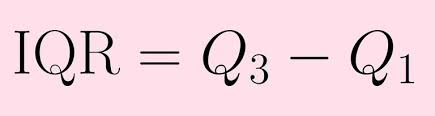

All of the measures that we discussed for spread are **sensitive** to extreme values. **IQR** is one measure which is not sensitive to outliers.

Lets calculate **minimum**, **maximum**, **variance**, and **standard deviation** values of variable mpg in the data.

```r
min(mtcars$mpg)
```

```
[1] 10.4
```

```r
max(mtcars$mpg)
```

```
[1] 33.9
```

```r
var(mtcars$mpg)
```

```
[1] 36.3241
```

```r
sd(mtcars$mpg)
```

```
[1] 6.026948
```

You can use summary function to generate a standard 6 point summary from a variable or entire data.

```r
summary(mtcars$mpg)
```

```
   Min. 1st Qu.  Median    Mean 3rd Qu.    Max.
  10.40   15.43   19.20   20.09   22.80   33.90
```

Lets see the summary of entire mtcars dataset

```r
summary(mtcars)
```

```
      mpg             cyl             disp             hp             drat             wt
 Min.   :10.40   Min.   :4.000   Min.   : 71.1   Min.   : 52.0   Min.   :2.760   Min.   :1.513
 1st Qu.:15.43   1st Qu.:4.000   1st Qu.:120.8   1st Qu.: 96.5   1st Qu.:3.080   1st Qu.:2.581
 Median :19.20   Median :6.000   Median :196.3   Median :123.0   Median :3.695   Median :3.325
 Mean   :20.09   Mean   :6.188   Mean   :230.7   Mean   :146.7   Mean   :3.597   Mean   :3.217
 3rd Qu.:22.80   3rd Qu.:8.000   3rd Qu.:326.0   3rd Qu.:180.0   3rd Qu.:3.920   3rd Qu.:3.610
 Max.   :33.90   Max.   :8.000   Max.   :472.0   Max.   :335.0   Max.   :4.930   Max.   :5.424
      qsec             vs               am              gear            carb
 Min.   :14.50   Min.   :0.0000   Min.   :0.0000   Min.   :3.000   Min.   :1.000
 1st Qu.:16.89   1st Qu.:0.0000   1st Qu.:0.0000   1st Qu.:3.000   1st Qu.:2.000
 Median :17.71   Median :0.0000   Median :0.0000   Median :4.000   Median :2.000
 Mean   :17.85   Mean   :0.4375   Mean   :0.4062   Mean   :3.688   Mean   :2.812
 3rd Qu.:18.90   3rd Qu.:1.0000   3rd Qu.:1.0000   3rd Qu.:4.000   3rd Qu.:4.000
 Max.   :22.90   Max.   :1.0000   Max.   :1.0000   Max.   :5.000   Max.   :8.000
```

# 1.4 Shapes of Distributions

Measures of central tendency and variability still do not tell how frequently a value occurs in your data or in other words, given a value what are the chances that it will be in the data.

To get an idea regarding the same we can plot frequency bar charts or histograms. The shape depicted by these histograms can be of **three types**:

1. **Symmetric**
2. **Positively Skewed**
3. **Negatively Skewed**

**Shape** is also represented in terms of distributions which we discuss in detail in hypothesis testing module.

For now you can understand symmetric shape to be where data values on either side of the mean are equally probable where as for positively and negatively skewed data has unbalanced properties.

For a symmetric shape:

**Q2 - Q1 = Q3 - Q2**

For positively skewed shape:

**Q2 - Q1 < Q3 - Q2**

For negatively skewed shape:

**Q2 - Q1 > Q3 - Q2**

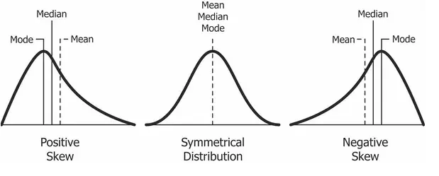

```r
str(mtcars)
```

```
'data.frame':   32 obs. of  11 variables:
 $ mpg : num  21 21 22.8 21.4 18.7 18.1 14.3 24.4 22.8 19.2 ...
 $ cyl : num  6 6 4 6 8 6 8 4 4 6 ...
 $ disp: num  160 160 108 258 360 ...
 $ hp  : num  110 110 93 110 175 105 245 62 95 123 ...
 $ drat: num  3.9 3.9 3.85 3.08 3.15 2.76 3.21 3.69 3.92 3.92 ...
 $ wt  : num  2.62 2.88 2.32 3.21 3.44 ...
 $ qsec: num  16.5 17 18.6 19.4 17 ...
 $ vs  : num  0 0 1 1 0 1 0 1 1 1 ...
 $ am  : num  1 1 1 0 0 0 0 0 0 0 ...
 $ gear: num  4 4 4 3 3 3 3 4 4 4 ...
 $ carb: num  4 4 1 1 2 1 4 2 2 4 ...
```

```r
library(dplyr)
```

```r
glimpse(mtcars)
```

```
Observations: 32
Variables: 11
$ mpg  <dbl> 21.0, 21.0, 22.8, 21.4, 18.7, 18.1, 14.3, 24.4, 22.8, 19.2, 17.8, 16.4, 17.3, 15....
$ cyl  <dbl> 6, 6, 4, 6, 8, 6, 8, 4, 4, 6, 6, 8, 8, 8, 8, 8, 8, 4, 4, 4, 4, 8, 8, 8, 8, 4, 4, ...
$ disp <dbl> 160.0, 160.0, 108.0, 258.0, 360.0, 225.0, 360.0, 146.7, 140.8, 167.6, 167.6, 275....
$ hp   <dbl> 110, 110, 93, 110, 175, 105, 245, 62, 95, 123, 123, 180, 180, 180, 205, 215, 230,...
$ drat <dbl> 3.90, 3.90, 3.85, 3.08, 3.15, 2.76, 3.21, 3.69, 3.92, 3.92, 3.92, 3.07, 3.07, 3.0...
$ wt   <dbl> 2.620, 2.875, 2.320, 3.215, 3.440, 3.460, 3.570, 3.190, 3.150, 3.440, 3.440, 4.07...
$ qsec <dbl> 16.46, 17.02, 18.61, 19.44, 17.02, 20.22, 15.84, 20.00, 22.90, 18.30, 18.90, 17.4...
$ vs   <dbl> 0, 0, 1, 1, 0, 1, 0, 1, 1, 1, 1, 0, 0, 0, 0, 0, 0, 1, 1, 1, 1, 0, 0, 0, 0, 1, 0, ...
$ am   <dbl> 1, 1, 1, 0, 0, 0, 0, 0, 0, 0, 0, 0, 0, 0, 0, 0, 0, 1, 1, 1, 0, 0, 0, 0, 0, 1, 1, ...
$ gear <dbl> 4, 4, 4, 3, 3, 3, 3, 4, 4, 4, 4, 3, 3, 3, 3, 3, 3, 4, 4, 4, 3, 3, 3, 3, 3, 4, 5, ...
$ carb <dbl> 4, 4, 1, 1, 2, 1, 4, 2, 2, 4, 4, 3, 3, 3, 4, 4, 4, 1, 2, 1, 1, 2, 2, 4, 2, 1, 2, ...
```

Lets start with looking at **class** of these outputs. If the class is something that we are not familiar with, we’ll next look for names of elements within the output in their class.

```r
summ = summary(mtcars$mpg)
summ
```

```
   Min. 1st Qu.  Median    Mean 3rd Qu.    Max.
  10.40   15.43   19.20   20.09   22.80   33.90
```

```r
class(summ)
```

```
[1] "summaryDefault" "table"
```

```r
names(summ)
```

```
[1] "Min."    "1st Qu." "Median"  "Mean"    "3rd Qu." "Max."
```

Now we know names of each components, we can use them to fetch the values:

```r
summ["Min."]
```

```
Min.
10.4
```

Now lets try the same with summary of entire data.

```r
sumry = summary(mtcars)
sumry
```

```
      mpg             cyl             disp             hp             drat             wt
 Min.   :10.40   Min.   :4.000   Min.   : 71.1   Min.   : 52.0   Min.   :2.760   Min.   :1.513
 1st Qu.:15.43   1st Qu.:4.000   1st Qu.:120.8   1st Qu.: 96.5   1st Qu.:3.080   1st Qu.:2.581
 Median :19.20   Median :6.000   Median :196.3   Median :123.0   Median :3.695   Median :3.325
 Mean   :20.09   Mean   :6.188   Mean   :230.7   Mean   :146.7   Mean   :3.597   Mean   :3.217
 3rd Qu.:22.80   3rd Qu.:8.000   3rd Qu.:326.0   3rd Qu.:180.0   3rd Qu.:3.920   3rd Qu.:3.610
 Max.   :33.90   Max.   :8.000   Max.   :472.0   Max.   :335.0   Max.   :4.930   Max.   :5.424
      qsec             vs               am              gear            carb
 Min.   :14.50   Min.   :0.0000   Min.   :0.0000   Min.   :3.000   Min.   :1.000
 1st Qu.:16.89   1st Qu.:0.0000   1st Qu.:0.0000   1st Qu.:3.000   1st Qu.:2.000
 Median :17.71   Median :0.0000   Median :0.0000   Median :4.000   Median :2.000
 Mean   :17.85   Mean   :0.4375   Mean   :0.4062   Mean   :3.688   Mean   :2.812
 3rd Qu.:18.90   3rd Qu.:1.0000   3rd Qu.:1.0000   3rd Qu.:4.000   3rd Qu.:4.000
 Max.   :22.90   Max.   :1.0000   Max.   :1.0000   Max.   :5.000   Max.   :8.000
```

```r
class(sumry)
```

```
[1] "table"
```

```r
names(sumry)
```

[output not shown]

This gets a little confusing. If outputs doesnt have any names, how can we access any of the output?

Lets try with numeric indices.

```r
sumry[1,2]
```

```
[1] "Min.   :4.000  "
```

There are other summary functions as well coming from different packages in R. We’ll look at one, that doesnt mean there are not others.

```r
library(psych)
```

```r
describe(mtcars)
```

|  | vars | n | mean | sd | median | trimmed | mad | min | max | range | skew | kurtosis | se |
| --- | --- | --- | --- | --- | --- | --- | --- | --- | --- | --- | --- | --- | --- |
| mpg | 1 | 32 | 20.09 | 6.03 | 19.20 | 19.70 | 5.41 | 10.40 | 33.90 | 23.50 | 0.61 | -0.37 | 1.07 |
| cyl | 2 | 32 | 6.19 | 1.79 | 6.00 | 6.23 | 2.97 | 4.00 | 8.00 | 4.00 | -0.17 | -1.76 | 0.32 |
| disp | 3 | 32 | 230.72 | 123.94 | 196.30 | 222.52 | 140.48 | 71.10 | 472.00 | 400.90 | 0.38 | -1.21 | 21.91 |
| hp | 4 | 32 | 146.69 | 68.56 | 123.00 | 141.19 | 77.10 | 52.00 | 335.00 | 283.00 | 0.73 | -0.14 | 12.12 |
| drat | 5 | 32 | 3.60 | 0.53 | 3.70 | 3.58 | 0.70 | 2.76 | 4.93 | 2.17 | 0.27 | -0.71 | 0.09 |
| wt | 6 | 32 | 3.22 | 0.98 | 3.33 | 3.15 | 0.77 | 1.51 | 5.42 | 3.91 | 0.42 | -0.02 | 0.17 |
| qsec | 7 | 32 | 17.85 | 1.79 | 17.71 | 17.83 | 1.42 | 14.50 | 22.90 | 8.40 | 0.37 | 0.34 | 0.32 |
| vs | 8 | 32 | 0.44 | 0.50 | 0.00 | 0.42 | 0.00 | 0.00 | 1.00 | 1.00 | 0.24 | -2.00 | 0.09 |
| am | 9 | 32 | 0.41 | 0.50 | 0.00 | 0.38 | 0.00 | 0.00 | 1.00 | 1.00 | 0.36 | -1.92 | 0.09 |
| gear | 10 | 32 | 3.69 | 0.74 | 4.00 | 3.62 | 1.48 | 3.00 | 5.00 | 2.00 | 0.53 | -1.07 | 0.13 |

[output cut: 1 more lines]

You can see that this gives much more detailed **summary** of the dataset. Lets try to acces these values as well.

```r
s = describe(mtcars)
s
```

|  | vars | n | mean | sd | median | trimmed | mad | min | max | range | skew | kurtosis | se |
| --- | --- | --- | --- | --- | --- | --- | --- | --- | --- | --- | --- | --- | --- |
| mpg | 1 | 32 | 20.09 | 6.03 | 19.20 | 19.70 | 5.41 | 10.40 | 33.90 | 23.50 | 0.61 | -0.37 | 1.07 |
| cyl | 2 | 32 | 6.19 | 1.79 | 6.00 | 6.23 | 2.97 | 4.00 | 8.00 | 4.00 | -0.17 | -1.76 | 0.32 |
| disp | 3 | 32 | 230.72 | 123.94 | 196.30 | 222.52 | 140.48 | 71.10 | 472.00 | 400.90 | 0.38 | -1.21 | 21.91 |
| hp | 4 | 32 | 146.69 | 68.56 | 123.00 | 141.19 | 77.10 | 52.00 | 335.00 | 283.00 | 0.73 | -0.14 | 12.12 |
| drat | 5 | 32 | 3.60 | 0.53 | 3.70 | 3.58 | 0.70 | 2.76 | 4.93 | 2.17 | 0.27 | -0.71 | 0.09 |
| wt | 6 | 32 | 3.22 | 0.98 | 3.33 | 3.15 | 0.77 | 1.51 | 5.42 | 3.91 | 0.42 | -0.02 | 0.17 |
| qsec | 7 | 32 | 17.85 | 1.79 | 17.71 | 17.83 | 1.42 | 14.50 | 22.90 | 8.40 | 0.37 | 0.34 | 0.32 |
| vs | 8 | 32 | 0.44 | 0.50 | 0.00 | 0.42 | 0.00 | 0.00 | 1.00 | 1.00 | 0.24 | -2.00 | 0.09 |
| am | 9 | 32 | 0.41 | 0.50 | 0.00 | 0.38 | 0.00 | 0.00 | 1.00 | 1.00 | 0.36 | -1.92 | 0.09 |
| gear | 10 | 32 | 3.69 | 0.74 | 4.00 | 3.62 | 1.48 | 3.00 | 5.00 | 2.00 | 0.53 | -1.07 | 0.13 |

[output cut: 1 more lines]

```r
class(s)
```

```
[1] "psych"      "describe"   "data.frame"
```

you can see that the underlying class of the output object is **data.frame**. Good news, we know how to access ths output.

Here rownames are variables names of the dataset mtcars, column names are summary stats name. So if I wanted to look at **max** value of variable gear.

```r
s["gear","max"]
```

```
[1] 5
```

or multiple summaries of multiple variables basically you can get any kind of subset from this data.frame

```r
s[c("gear","mpg","wt"),c("max","sd","skew")]
```

|  | max | sd | skew |
| --- | --- | --- | --- |
| gear | 5.00 | 0.74 | 0.53 |
| mpg | 33.90 | 6.03 | 0.61 |
| wt | 5.42 | 0.98 | 0.42 |

To get an idea about shape of a variable , we can plot **boxplot** and **histograms**.

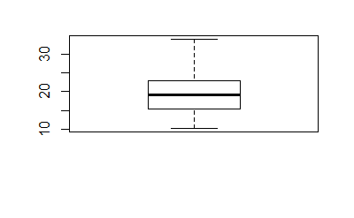

```r
boxplot(mtcars$mpg)
```

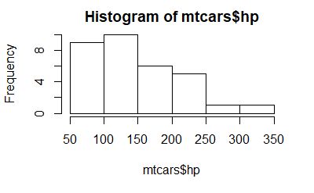

```r
hist(mtcars$hp,breaks=10)
```

# 1.5 Use Case: **Arthritis** Dataset

So far we have been looking at summaries of numeric variables only. How do we start to summarize categorical variables?

Maximum that we can do is to look at what distinct values a **categorical variable** takes and what are the frequencies of these values in the data.

**Cross tables** between two or more categorical variable is also a great source of insights. To learn how to do that in R, we’ll be using datasets **Arthritis** from package **vcd**.

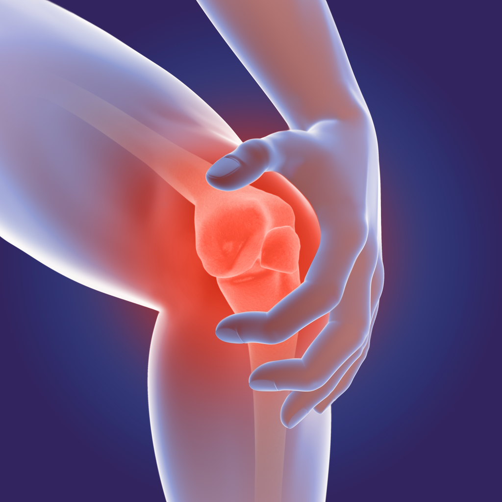

```r
library(vcd)
```

```r
data(Arthritis)
```

```r
View(Arthritis)
```

You can get details of the data set by running **?Arthritis**.

To get simple frequency table of single variable you can use function **table**.

```r
freq = table(Arthritis$Improved)
freq
```

```
  None   Some Marked
    42     14     28
```

You can convert these counts to percentage by apply function **prop.table** on the output of function table.

```r
prop.table(freq)
```

```
     None      Some    Marked
0.5000000 0.1666667 0.3333333
```

You can apply round off to this output or convert it to proper percentages by multiplying by 100

```r
round(prop.table(freq),2)
```

```
  None   Some Marked
  0.50   0.17   0.33
```

```r
prop.table(freq)*100
```

```
    None     Some   Marked
50.00000 16.66667 33.33333
```

For creating cross tables between two or more variables , you can either use function **table** or **xtabs**.

```r
table(Arthritis$Improved,Arthritis$Sex)
```

```
         Female Male
  None       25   17
  Some       12    2
  Marked     22    6
```

```r
xtabs(~Improved + Sex, data = Arthritis)
```

```
        Sex
Improved Female Male
  None       25   17
  Some       12    2
  Marked     22    6
```

```r
cross_tab = xtabs(~Treatment + Improved, data = Arthritis)
cross_tab
```

```
         Improved
Treatment None Some Marked
  Placebo   29    7      7
  Treated   13    7     21
```

Applying **prop.table** on this count table will give you overall percentages, but you might interested in percetnage across a particular dimension.

You can achieve that by supplying dimension number as second argument.

```r
prop.table(cross_tab)
```

```
         Improved
Treatment       None       Some     Marked
  Placebo 0.34523810 0.08333333 0.08333333
  Treated 0.15476190 0.08333333 0.25000000
```

```r
prop.table(cross_tab,1)
```

```
         Improved
Treatment      None      Some    Marked
  Placebo 0.6744186 0.1627907 0.1627907
  Treated 0.3170732 0.1707317 0.5121951
```

```r
prop.table(cross_tab,2)
```

```
         Improved
Treatment      None      Some    Marked
  Placebo 0.6904762 0.5000000 0.2500000
  Treated 0.3095238 0.5000000 0.7500000
```

**margin.tables** does not look like a very useful function at this point of time when we are looking at two way tables only, it will have more utility if used with higher dimension cross tables.

```r
margin.table(cross_tab)
```

```
[1] 84
```

```r
margin.table(cross_tab,1)
```

```
Treatment
Placebo Treated
     43      41
```

```r
margin.table(cross_tab,2)
```

```
Improved
  None   Some Marked
    42     14     28
```

For now, the next thing that we are going to discuss is, adding sum across a dimension without collapsing the table. This can be done using **addmargins** function.

```r
addmargins(cross_tab)
```

```
         Improved
Treatment None Some Marked Sum
  Placebo   29    7      7  43
  Treated   13    7     21  41
  Sum       42   14     28  84
```

```r
addmargins(cross_tab, 1)
```

```
         Improved
Treatment None Some Marked
  Placebo   29    7      7
  Treated   13    7     21
  Sum       42   14     28
```

```r
addmargins(cross_tab, 2)
```

```
         Improved
Treatment None Some Marked Sum
  Placebo   29    7      7  43
  Treated   13    7     21  41
```

Now, we’ll look at a **three-way cross table**. To make the display more intuitive we’ll use function **ftable**.

Keep in mind that this function doesn’t change counts in any manner, it just changes the way count table is being displayed.

```r
cro_tab= xtabs(~Treatment+Sex+Improved,data=Arthritis)
cro_tab
```

```
, , Improved = None

         Sex
Treatment Female Male
  Placebo     19   10
  Treated      6    7

, , Improved = Some

         Sex
Treatment Female Male
  Placebo      7    0
  Treated      5    2

, , Improved = Marked

         Sex
Treatment Female Male
  Placebo      6    1
  Treated     16    5
```

```r
ftable(cro_tab)
```

```
                 Improved None Some Marked
Treatment Sex
Placebo   Female            19    7      6
          Male              10    0      1
Treated   Female             6    5     16
          Male               7    2      5
```

Applying **margin.table** on this with individul dimension index or a vector index produces appropriate collpased tables.

```r
margin.table(cro_tab,1)
```

```
Treatment
Placebo Treated
     43      41
```

```r
margin.table(cro_tab,c(1,3))
```

```
         Improved
Treatment None Some Marked
  Placebo   29    7      7
  Treated   13    7     21
```

Here is an example of applying prop.table with dimension vector.

```r
ftable(prop.table(cro_tab,c(1,3)))
```

```
                 Improved      None      Some    Marked
Treatment Sex
Placebo   Female          0.6551724 1.0000000 0.8571429
          Male            0.3448276 0.0000000 0.1428571
Treated   Female          0.4615385 0.7142857 0.7619048
          Male            0.5384615 0.2857143 0.2380952
```

To understand the output better here, we are going to add margins to the output as well

```r
ftable(addmargins(prop.table(cro_tab,c(1,2)),3))
```

```
                 Improved       None       Some     Marked        Sum
Treatment Sex
Placebo   Female          0.59375000 0.21875000 0.18750000 1.00000000
          Male            0.90909091 0.00000000 0.09090909 1.00000000
Treated   Female          0.22222222 0.18518519 0.59259259 1.00000000
          Male            0.50000000 0.14285714 0.35714286 1.00000000
```